# Research Question 2

Anran Huang

10/05/2021

```r
# check package availability
list.of.packages <- c("ggplot2", "epiDisplay", "ROSE", "caret" ,"effects",
                      "GGally", "compiler", "parallel", "devtools", "texreg",
                      "texreghelpr")
new.packages <- list.of.packages[!(list.of.packages %in% installed.packages()[,"Package"])]
if(length(new.packages)) install.packages(new.packages)

#load packages
library(nlme)
library(ggplot2)
library(lme4)
library(nlme)
library(dplyr)
library(caret)
library(tidyr)
require(GGally)
require(reshape2)
require(compiler)
require(parallel)
require(boot)
require(lattice)
library(devtools)
library(texreg)
install_github("SarBearSchwartz/texreghelpr")
library(texreghelpr)


icudata <- read.csv('1_input/input_rq2.csv')
paste(nrow(icudata), 'rows of data')
```

```
## [1] "61516 rows of data"
```

```r
paste(length(unique(icudata$icustay_id)), 'unique ICU stays in the dataset')
```

```
## [1] "61516 unique ICU stays in the dataset"
```

```r
paste(length(unique(icudata$hadm_id)), 'unique hospital admissions in the dataset')
```

```
## [1] "57771 unique hospital admissions in the dataset"
```

```r
paste(length(unique(icudata$subject_id)), 'patients in the dataset')
```

```
## [1] "46464 patients in the dataset"
```

## Data Preparation

```r
colnames(icudata)[8] <- 'ICU_mortality'
data_long <- icudata %>%
  group_by(hadm_id) %>%
  mutate(icustay_idx = row_number()) %>% ungroup() %>%
  dplyr::mutate(hadm_id = factor(hadm_id),
                subject_id = factor(subject_id),
                age_bins = factor(age_bins,
                                  order = TRUE,
                                  levels = c("under44", "45-54", "55-64", "65-74", "over75")),
                icu_adm_weekend = as.logical.factor((icu_adm_weekend),
                                                    levels = c(FALSE, TRUE),
                                                    labels = c("Weekday", "Weekend")),
                ICU_mortality = as.factor(as.integer(as.integer(ICU_mortality)-1)),
                ICU_mortality_int = as.integer(ICU_mortality),
                icu_adm_weekend = factor((icu_adm_weekend),
                                         levels = c(FALSE, TRUE),
                                         labels = c("Weekday", "Weekend"))) %>%
  select(-c(icustay_id)) %>%
  dplyr::arrange(hadm_id, icustay_idx)
str(data_long)
```

```
## tibble[,13] [61,516 × 13] (S3: tbl_df/tbl/data.frame)
##  $ X                : int [1:61516] 47646 46273 12580 29141 697 46718 57447 48216 51039 20543 ...
##  $ subject_id       : Factor w/ 46464 levels "2","3","4","5",..: 35648 34600 9342 21685 503 34937 43304 36079 38308 15315 ...
##  $ hadm_id          : Factor w/ 57771 levels "100001","100003",..: 1 2 3 4 5 6 7 8 9 10 ...
##  $ age_years        : num [1:61516] 35 59 48 73 60 54 21 67 55 27 ...
##  $ age_bins         : Ord.factor w/ 5 levels "under44"<"45-54"<..: 1 3 2 4 3 2 1 4 3 1 ...
##  $ icu_adm_weekend  : Factor w/ 2 levels "Weekday","Weekend": 2 1 1 1 1 1 1 1 2 2 ...
##  $ ICU_mortality    : Factor w/ 2 levels "0","1": 1 1 1 1 1 1 1 1 1 1 ...
##  $ los              : num [1:61516] 4.26 1.94 4.98 4.1 2.49 ...
##  $ re_adm_in30d     : Factor w/ 2 levels "False","True": 1 1 1 1 1 1 1 1 1 1 ...
##  $ insurance        : Factor w/ 5 levels "government","medicaid",..: 4 4 4 4 4 4 2 3 3 2 ...
##  $ admission_type   : Factor w/ 4 levels "elective","emergency",..: 2 2 2 2 2 1 2 2 2 4 ...
##  $ icustay_idx      : int [1:61516] 1 1 1 1 1 1 1 1 1 1 ...
##  $ ICU_mortality_int: int [1:61516] 1 1 1 1 1 1 1 1 1 1 ...
```

## Data Visualisation

The longitudinal data set is seriously imbalanced. 93% of the cases are negative and only 7% are positive (i.e. ICU mortality).

```r
round(prop.table(table(data_long$ICU_mortality)),3)
```

```
##
##    0    1
## 0.93 0.07
```

```r
cross.tab <- xtabs(~icu_adm_weekend+ICU_mortality, data=data_long)
icu.crosstab <- t(cross.tab[2:1,2:1])
addmargins(icu.crosstab) #cross tab
```

```
##              icu_adm_weekend
## ICU_mortality Weekend Weekday   Sum
##           1      1143    3180  4323
##           0     12453   44740 57193
##           Sum   13596   47920 61516
```

```r
round(prop.table(icu.crosstab,1),3) # row perc
```

```
##              icu_adm_weekend
## ICU_mortality Weekend Weekday
##             1   0.264   0.736
##             0   0.218   0.782
```

```r
round(prop.table(icu.crosstab,2),3) # column perc
```

```
##              icu_adm_weekend
## ICU_mortality Weekend Weekday
##             1   0.084   0.066
##             0   0.916   0.934
```

```r
round(prop.table(icu.crosstab),3) # cell perc
```

```
##              icu_adm_weekend
## ICU_mortality Weekend Weekday
##             1   0.019   0.052
##             0   0.202   0.727
```

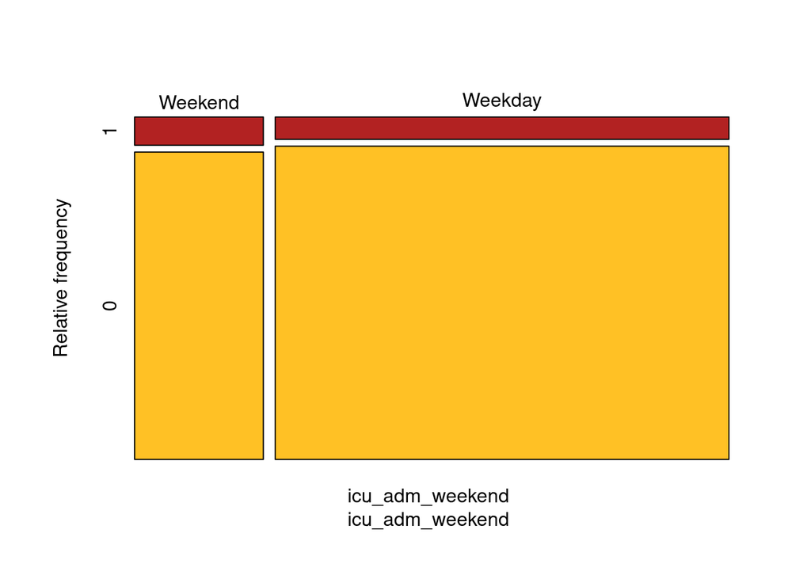

```r
mosaicplot( t(icu.crosstab), col = c("firebrick", "goldenrod1"), cex.axis = 1, sub = "icu_adm_weekend", ylab = "Relative frequency", main = "")
```

```r
if (!require("epitools")) {install.packages("epitools", dependencies = TRUE, repos="http://cran.rstudio.com/")}
library(epitools)
cat("odds ratio: \n")
```

```
## odds ratio:
```

```r
oddsratio(icu.crosstab, method = "wald")$measure[-1,]
```

```
## estimate    lower    upper
## 1.291341 1.203497 1.385598
```

```r
cat("risk ratio: \n")
```

```
## risk ratio:
```

```r
riskratio(icu.crosstab, method = "wald", rev = "both")$measure[-1,]
```

```
## estimate    lower    upper
## 1.214311 1.152675 1.279243
```

```
## Frequency Table for icustay_idx
```

```
## data_long[, c(i)] :
##         Frequency Percent
## 1           57771    93.9
## 2            3259     5.3
## 3             395     0.6
## 4              69     0.1
## 5              15     0.0
## 6               5     0.0
## 7               2     0.0
##   Total     61516   100.0
## Frequency Table for age_bins
```

```
## data_long[, c(i)] :
##         Frequency Percent
## over75      16599    27.0
## under44     15742    25.6
## 65-74       10918    17.7
## 55-64       10576    17.2
## 45-54        7681    12.5
##   Total     61516   100.0
## Frequency Table for icu_adm_weekend
```

```
## data_long[, c(i)] :
##         Frequency Percent
## Weekday     47920    77.9
## Weekend     13596    22.1
##   Total     61516   100.0
## Frequency Table for re_adm_in30d
```

```
## data_long[, c(i)] :
##         Frequency Percent
## False       57936    94.2
## True         3580     5.8
##   Total     61516   100.0
## Frequency Table for insurance
```

```
## data_long[, c(i)] :
##            Frequency Percent
## medicare       29806    48.5
## private        23235    37.8
## medicaid        6016     9.8
## government      1837     3.0
## selfpay          622     1.0
##   Total        61516   100.0
## Frequency Table for admission_type
```

```
## data_long[, c(i)] :
##           Frequency Percent
## emergency     44777    72.8
## newborn        7871    12.8
## elective       7453    12.1
## urgent         1415     2.3
##   Total       61516   100.0
```

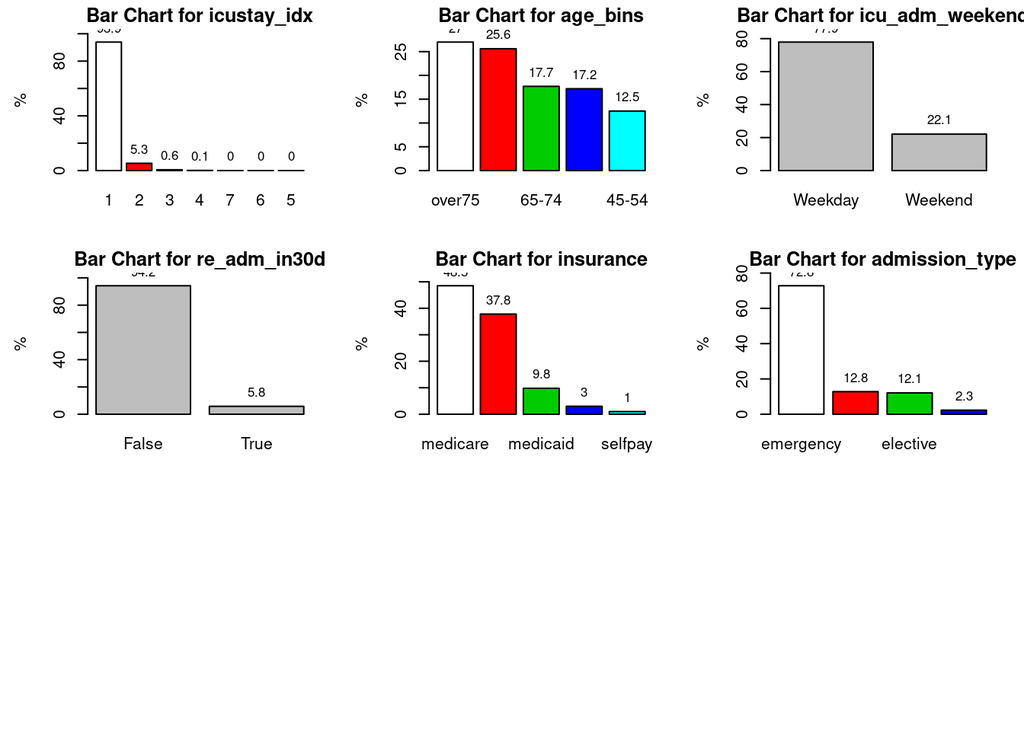

```r
par(mfrow = c(3,3), mar=c(0.5, 0.5, 0.2, 0.2),
     mai=c(.5,.6,.2,.2))
loop.vector <- c("icustay_idx", "age_bins", "icu_adm_weekend", "re_adm_in30d", "insurance", "admission_type")

for (i in loop.vector) {
  cat(paste("Frequency Table for", i, '\n'))
  print(epiDisplay::tab1(data_long[,c(i)], sort.group ='decreasing', cum.percent = FALSE, graph=TRUE, cex=0.8, bar.values='percent', main=paste("Bar Chart for",i)))
}
```

```r
print(data_long %>% group_by(ICU_mortality) %>%
        summarise(median_los = median(los),
                  qntl_25 = quantile(los, 0.25),
                  qntl_75 = quantile(los, 0.75),
                  ))
```

```
## # A tibble: 2 x 4
##   ICU_mortality median_los qntl_25 qntl_75
##   <fct>              <dbl>   <dbl>   <dbl>
## 1 0                   2.10   1.12     4.62
## 2 1                   2.00   0.964    3.72
```

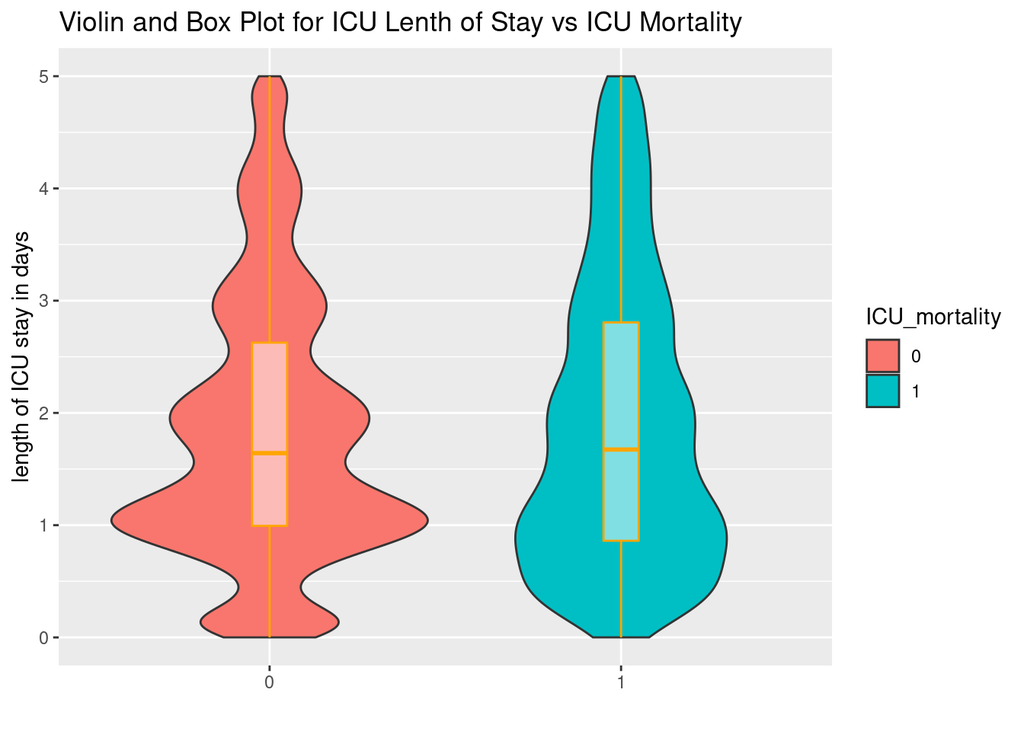

```r
data_long %>%
  ggplot(aes(x=ICU_mortality, y=los, fill=ICU_mortality)) +
  geom_violin() +
  ylab("length of ICU stay in days") +
  geom_boxplot(width=0.1, color="orange", fill='white', alpha=0.5)+
  ylim(0, 5)+
  #scale_y_continuous(limits = quantile(data_long$los, c(0, 0.9)))+
  ggtitle("Violin and Box Plot for ICU Lenth of Stay vs ICU Mortality") +
  xlab("")
```

## Chi-squared contingency test to test association between ICU weekend admission and ICU mortality rate

```r
icu_ChiTest <- chisq.test(data_long$ICU_mortality, data_long$icu_adm_weekend, correct = FALSE)
icu_ChiTest
```

```
##
##  Pearson's Chi-squared test
##
## data:  data_long$ICU_mortality and data_long$icu_adm_weekend
## X-squared = 50.832, df = 1, p-value = 1.006e-12
```

```r
addmargins(icu_ChiTest$expected)
```

```
##                        data_long$icu_adm_weekend
## data_long$ICU_mortality   Weekday    Weekend   Sum
##                     0   44552.451 12640.5493 57193
##                     1    3367.549   955.4507  4323
##                     Sum 47920.000 13596.0000 61516
```

```r
source("http://www.stat.wisc.edu/~st571-1/gtest.R")
g.test(icu.crosstab)
```

```
## G-Test for Contingency Tables
##
## Data:
##              icu_adm_weekend
## ICU_mortality Weekend Weekday
##             1    1143    3180
##             0   12453   44740
##
## The test statistic is  48.8474 .
## There are  1  degrees of freedom.
## The p-value is  2.766787e-12 .
```

## Under-sampling for Label Imbalance

```r
data_long$age_group = as.integer(data_long$age_bins)
sliced = data_long[,c("ICU_mortality", "hadm_id", "subject_id", "los", "age_group", "icu_adm_weekend", "re_adm_in30d", "insurance", "admission_type")]
under_sample <- ROSE::ovun.sample(data=sliced, ICU_mortality ~ .,method = "under", N = 4323*2, seed = 1)$data
```

```r
xtabs(~age_group+ICU_mortality, data=data_long)
```

```
##          ICU_mortality
## age_group     0     1
##         1 15394   348
##         2  7254   427
##         3  9919   657
##         4 10122   796
##         5 14504  2095
```

## Simple Generalised Logistic Regression Model (SLR)

```r
model_slm0 <- glm(ICU_mortality ~ icu_adm_weekend, data = under_sample, family = binomial)
# Summarize the model
summary(model_slm0)
```

```
##
## Call:
## glm(formula = ICU_mortality ~ icu_adm_weekend, family = binomial,
##     data = under_sample)
##
## Deviance Residuals:
##      Min        1Q    Median        3Q       Max
## -1.27086  -1.14877  -0.03101   1.20632   1.20632
##
## Coefficients:
##                        Estimate Std. Error z value Pr(>|z|)
## (Intercept)            -0.06778    0.02466  -2.748    0.006 **
## icu_adm_weekendWeekend  0.28481    0.05070   5.618 1.93e-08 ***
## ---
## Signif. codes:  0 '***' 0.001 '**' 0.01 '*' 0.05 '.' 0.1 ' ' 1
##
## (Dispersion parameter for binomial family taken to be 1)
##
##     Null deviance: 11986  on 8645  degrees of freedom
## Residual deviance: 11954  on 8644  degrees of freedom
## AIC: 11958
##
## Number of Fisher Scoring iterations: 3
```

```r
model_slm0$coefficients
```

```
##            (Intercept) icu_adm_weekendWeekend
##             -0.0677762              0.2848142
```

```r
confint(model_slm0)
```

```
##                             2.5 %      97.5 %
## (Intercept)            -0.1161328 -0.01944606
## icu_adm_weekendWeekend  0.1855476  0.38429465
```

```r
probabilities0 <-model_slm0 %>% predict(data_long, type = "response")
predicted.classes0 <- ifelse(probabilities0 > 0.5, 1, 0)
cat("model accuracy on predicting ICU mortality:", mean(predicted.classes0 == data_long$ICU_mortality))
```

```
## model accuracy on predicting ICU mortality: 0.745871
```

```r
# use caret and compute a confusion matrix
caret::confusionMatrix(data = as.factor(predicted.classes0), reference = data_long$ICU_mortality)
```

```
## Confusion Matrix and Statistics
##
##           Reference
## Prediction     0     1
##          0 44740  3180
##          1 12453  1143
##
##                Accuracy : 0.7459
##                  95% CI : (0.7424, 0.7493)
##     No Information Rate : 0.9297
##     P-Value [Acc > NIR] : 1
##
##                   Kappa : 0.0234
##
##  Mcnemar's Test P-Value : <2e-16
##
##             Sensitivity : 0.78226
##             Specificity : 0.26440
##          Pos Pred Value : 0.93364
##          Neg Pred Value : 0.08407
##              Prevalence : 0.92973
##          Detection Rate : 0.72729
##    Detection Prevalence : 0.77898
##       Balanced Accuracy : 0.52333
##
##        'Positive' Class : 0
##
```

## Multilevel Linear Model for Binary Outcome (MLM)

We are interested in investigating whether weekend ICU admission increases the risk of ICU mortality.

- RI: outcome may change for each hospital admission `icu_adm_weekend`;

Random slope models are generally not recommended for binomial GLMMs.

By comparing the log-likelihood of single-level intercept-only model and a variance-components (VC) model, it does appear the VC model with a random intercept is better than a single-level model. As expected, the confidence interval is wider for the VC model as the single-level is often over-confident. VPC of 0.6 at hospital admission level, which is not too large nor close to zero. It suggests that there is an impact on `ICU_mortality` by `hadm_id`, i.e. risk of `ICU_mortality` varies among `hadm_id`s.

```r
under_sample$ICU_mortality = as.numeric(under_sample$ICU_mortality)
mod.single <- lm(ICU_mortality ~ 1, data=under_sample)
mod.vc.hosp <- lmer(ICU_mortality ~ (1|hadm_id), data=under_sample, REML=FALSE)
mod.vc.pt <- lmer(ICU_mortality ~ (1|subject_id), data=under_sample, REML=FALSE)

VPC.hosp <- VarCorr(mod.vc.hosp) %>% as_tibble() %>% mutate(icc=vcov/sum(vcov)) %>% select(grp, icc)
VPC.pt <- VarCorr(mod.vc.pt) %>% as_tibble() %>% mutate(icc=vcov/sum(vcov)) %>% select(grp, icc)

print(VPC.hosp[0:1,])
```

```
## # A tibble: 1 x 2
##   grp       icc
##   <chr>   <dbl>
## 1 hadm_id 0.604
```

```r
print(VPC.pt[0:1,])
```

```
## # A tibble: 1 x 2
##   grp          icc
##   <chr>      <dbl>
## 1 subject_id 0.277
```

```r
logLik(mod.single)
```

```
## 'log Lik.' -6275.192 (df=2)
```

```r
logLik(mod.vc.hosp)
```

```
## 'log Lik.' -6236.744 (df=3)
```

```r
logLik(mod.vc.pt)
```

```
## 'log Lik.' -6258.224 (df=3)
```

```r
confint(mod.single)
```

```
##                2.5 %   97.5 %
## (Intercept) 1.489459 1.510541
```

```r
confint(mod.vc.hosp)
```

```
## Computing profile confidence intervals ...
```

```
##                 2.5 %    97.5 %
## .sig01      0.3563489 0.4129950
## .sigma      0.2843949 0.3498055
## (Intercept) 1.4855261 1.5067734
```

```r
confint(mod.vc.pt)
```

```
## Computing profile confidence intervals ...
```

```
##                 2.5 %    97.5 %
## .sig01      0.2158862 0.3008198
## .sigma      0.3999058 0.4513387
## (Intercept) 1.4900999 1.5114083
```

```r
under_sample$ICU_mortality = as.factor(under_sample$ICU_mortality)
# random intercept model 1
mod1 <- glmer(ICU_mortality ~ icu_adm_weekend + (1|hadm_id), data=under_sample, family = binomial(link = "logit"))

# additional model considering age_group
mod2 <- glmer(ICU_mortality ~ icu_adm_weekend + age_group + (1|hadm_id), data=under_sample, family = binomial(link = "logit"))

# additional model considering age_group * icu_adm_weekend
mod3 <- glmer(ICU_mortality ~ icu_adm_weekend*age_group + (1|hadm_id), data=under_sample, family = binomial(link = "logit"))
```

```r
confint(mod1)
```

```
## Computing profile confidence intervals ...
```

```
##                             2.5 %      97.5 %
## .sig01                  0.0000000  0.47714990
## (Intercept)            -0.1198895 -0.02066503
## icu_adm_weekendWeekend  0.1892829  0.39340134
```

```r
summary(mod1)
```

```
## Generalized linear mixed model fit by maximum likelihood (Laplace
##   Approximation) [glmerMod]
##  Family: binomial  ( logit )
## Formula: ICU_mortality ~ icu_adm_weekend + (1 | hadm_id)
##    Data: under_sample
##
##      AIC      BIC   logLik deviance df.resid
##  11957.9  11979.1  -5976.0  11951.9     8643
##
## Scaled residuals:
##     Min      1Q  Median      3Q     Max
## -1.1403 -0.9445 -0.0412  1.0116  1.0374
##
## Random effects:
##  Groups  Name        Variance Std.Dev.
##  hadm_id (Intercept) 0.09322  0.3053
## Number of obs: 8646, groups:  hadm_id, 8478
##
## Fixed effects:
##                        Estimate Std. Error z value Pr(>|z|)
## (Intercept)            -0.07016    0.02530  -2.773  0.00555 **
## icu_adm_weekendWeekend  0.29097    0.05204   5.591 2.26e-08 ***
## ---
## Signif. codes:  0 '***' 0.001 '**' 0.01 '*' 0.05 '.' 0.1 ' ' 1
##
## Correlation of Fixed Effects:
##             (Intr)
## ic_dm_wkndW -0.489
```

```r
logLik(mod1)
```

```
## 'log Lik.' -5975.974 (df=3)
```

```r
logLik(model_slm0)
```

```
## 'log Lik.' -5977.097 (df=2)
```

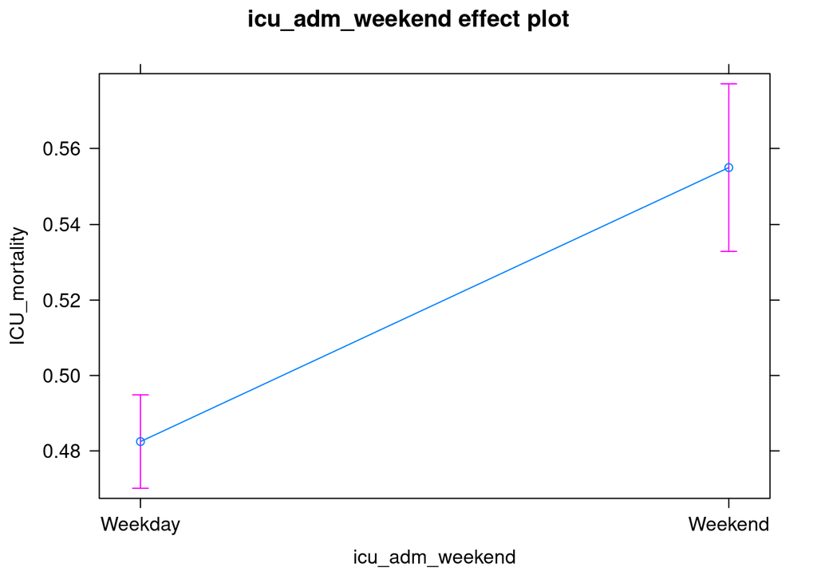

```r
plot(effects::allEffects(mod1))
```

```r
texreg::knitreg(list(mod1, mod2),
                custom.model.names = c("without age group", "with age group"),
                single.row = TRUE,
                caption = "MLM Parameter Estimates: Inclusion of Age Group at Hospital Admission (SE and p-values)")
```

```
## <table class="texreg" style="margin: 10px auto;border-collapse: collapse;border-spacing: 0px;caption-side: bottom;color: #000000;border-top: 2px solid #000000;">
## <caption>MLM Parameter Estimates: Inclusion of Age Group at Hospital Admission (SE and p-values)</caption>
## <thead>
## <tr>
## <th style="padding-left: 5px;padding-right: 5px;">&nbsp;</th>
## <th style="padding-left: 5px;padding-right: 5px;">without age group</th>
## <th style="padding-left: 5px;padding-right: 5px;">with age group</th>
## </tr>
## </thead>
## <tbody>
## <tr style="border-top: 1px solid #000000;">
## <td style="padding-left: 5px;padding-right: 5px;">(Intercept)</td>
## <td style="padding-left: 5px;padding-right: 5px;">-0.07 (0.03)<sup>\*\*</sup></td>
## <td style="padding-left: 5px;padding-right: 5px;">-1.51 (0.07)<sup>\*\*\*</sup></td>
## </tr>
## <tr>
## <td style="padding-left: 5px;padding-right: 5px;">icu_adm_weekendWeekend</td>
## <td style="padding-left: 5px;padding-right: 5px;">0.29 (0.05)<sup>\*\*\*</sup></td>
## <td style="padding-left: 5px;padding-right: 5px;">0.34 (0.05)<sup>\*\*\*</sup></td>
## </tr>
## <tr>
## <td style="padding-left: 5px;padding-right: 5px;">age_group</td>
## <td style="padding-left: 5px;padding-right: 5px;">&nbsp;</td>
## <td style="padding-left: 5px;padding-right: 5px;">0.41 (0.02)<sup>\*\*\*</sup></td>
## </tr>
## <tr style="border-top: 1px solid #000000;">
## <td style="padding-left: 5px;padding-right: 5px;">AIC</td>
## <td style="padding-left: 5px;padding-right: 5px;">11957.95</td>
## <td style="padding-left: 5px;padding-right: 5px;">11245.75</td>
## </tr>
## <tr>
## <td style="padding-left: 5px;padding-right: 5px;">BIC</td>
## <td style="padding-left: 5px;padding-right: 5px;">11979.14</td>
## <td style="padding-left: 5px;padding-right: 5px;">11274.01</td>
## </tr>
## <tr>
## <td style="padding-left: 5px;padding-right: 5px;">Log Likelihood</td>
## <td style="padding-left: 5px;padding-right: 5px;">-5975.97</td>
## <td style="padding-left: 5px;padding-right: 5px;">-5618.87</td>
## </tr>
## <tr>
## <td style="padding-left: 5px;padding-right: 5px;">Num. obs.</td>
## <td style="padding-left: 5px;padding-right: 5px;">8646</td>
## <td style="padding-left: 5px;padding-right: 5px;">8646</td>
## </tr>
## <tr>
## <td style="padding-left: 5px;padding-right: 5px;">Num. groups: hadm_id</td>
## <td style="padding-left: 5px;padding-right: 5px;">8478</td>
## <td style="padding-left: 5px;padding-right: 5px;">8478</td>
## </tr>
## <tr style="border-bottom: 2px solid #000000;">
## <td style="padding-left: 5px;padding-right: 5px;">Var: hadm_id (Intercept)</td>
## <td style="padding-left: 5px;padding-right: 5px;">0.09</td>
## <td style="padding-left: 5px;padding-right: 5px;">0.11</td>
## </tr>
## </tbody>
## <tfoot>
## <tr>
## <td style="font-size: 0.8em;" colspan="3"><sup>\*\*\*</sup>p &lt; 0.001; <sup>\*\*</sup>p &lt; 0.01; <sup>\*</sup>p &lt; 0.05</td>
## </tr>
## </tfoot>
## </table>
```

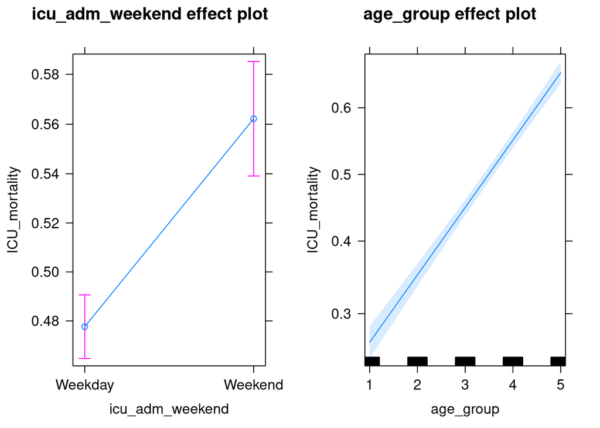

```r
plot(effects::allEffects(mod2))
```

```r
texreg::knitreg(list(extract_glmer_exp(mod1),
                     extract_glmer_exp(mod2)),
                custom.model.names = c("without age group", "with age group"),
                ci.test = 1,
                single.row = TRUE,
                caption = "MLM Parameter Estimates: Inclusion of Age Group at Hospital Admission (95% CI's)")
```

```
## <table class="texreg" style="margin: 10px auto;border-collapse: collapse;border-spacing: 0px;caption-side: bottom;color: #000000;border-top: 2px solid #000000;">
## <caption>MLM Parameter Estimates: Inclusion of Age Group at Hospital Admission (95% CI's)</caption>
## <thead>
## <tr>
## <th style="padding-left: 5px;padding-right: 5px;">&nbsp;</th>
## <th style="padding-left: 5px;padding-right: 5px;">without age group</th>
## <th style="padding-left: 5px;padding-right: 5px;">with age group</th>
## </tr>
## </thead>
## <tbody>
## <tr style="border-top: 1px solid #000000;">
## <td style="padding-left: 5px;padding-right: 5px;">(Intercept)</td>
## <td style="padding-left: 5px;padding-right: 5px;">0.93 [0.89; 0.98]<sup>\*</sup></td>
## <td style="padding-left: 5px;padding-right: 5px;">0.22 [0.19; 0.25]<sup>\*</sup></td>
## </tr>
## <tr>
## <td style="padding-left: 5px;padding-right: 5px;">icu_adm_weekendWeekend</td>
## <td style="padding-left: 5px;padding-right: 5px;">1.34 [1.21; 1.48]<sup>\*</sup></td>
## <td style="padding-left: 5px;padding-right: 5px;">1.40 [1.26; 1.56]<sup>\*</sup></td>
## </tr>
## <tr style="border-bottom: 2px solid #000000;">
## <td style="padding-left: 5px;padding-right: 5px;">age_group</td>
## <td style="padding-left: 5px;padding-right: 5px;">&nbsp;</td>
## <td style="padding-left: 5px;padding-right: 5px;">1.51 [1.46; 1.56]<sup>\*</sup></td>
## </tr>
## </tbody>
## <tfoot>
## <tr>
## <td style="font-size: 0.8em;" colspan="3"><sup>*</sup> Null hypothesis value outside the confidence interval.</td>
## </tr>
## </tfoot>
## </table>
```